# Buoy Project Report

Fall 2020 MA615 Assignment 1

Yuelin Jiang

9/25/2020

## Buoy data and Global Warming

This report is a limited data exploratory analysis of Buoy data from the NOAA National Data Buoy Center, NDBC Station 44013. The buoy data is collected every hour from December 1987 to December 2016. My task is to extrapolate useful variables and try to measure global warming based on these 30 year data.

## My Method

Abstract data of year 1987 to 2016 from the NDBC website, only keep the columns of year, month, day, hours, air temperature and water temperature. Transform temperatures to doubles and year month day hours to integers.

I only explore air temperature and water temperature at noon(hh=12), as the representative of the highest temperature for the day. Then I calculate the average monthly temperature for each year, using these daily noon temperatures. The reason why I only select temperature at noon is to avoid daily fluctuations which will affect the mean, so I pick one hour of the day to be consistent.

## Data Analysis

### Time Series Model

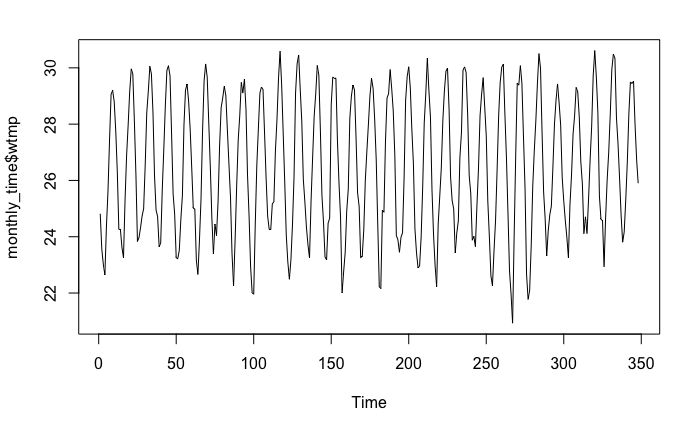

The overall trend of temperatures is hard to observe because of the seasonal change.

Using the time series sarima forecast function to predict the seasonal trend we have shown in Figure 3.

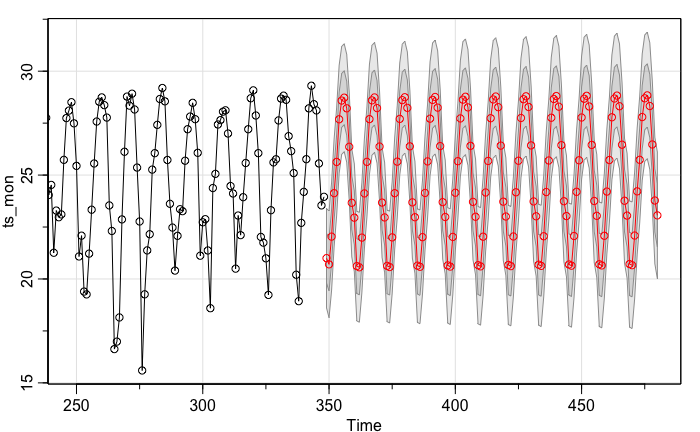

There are big fluctuations of this prediction and the overall trend is still unclear.

### Linear Model

To overcome this seasonal change within each year, I proceed to run separate regressions for each month, so I have 12 regressions for each month, where temperature is a function of year.

If there is indeed global warming, I should expect most of the months’ average temperatures rising over the years. If there is climate change where weathers become more extreme, then I should observe summer temperatures rising and winter temperatures decreasing.

After cleaning and preparing the data, I used a for loop to do each linear regression and plotting. For example, at each loop for i, I group all the months that equals to i into a separate dataframe. Then I used lm() to regress temperature against year.

Depending on the coefficient of the slope, I draw the abline() red if the coefficient >0(increasing temp), and blue if the coefficient <0 (decreasing temp). The results for Air Temperatures are shown in Figure4:

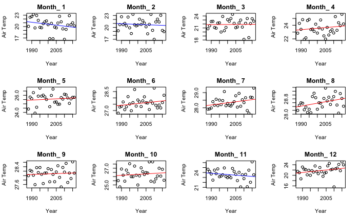

Each Month’s Average Air Temperature at Noon from 1987 to 2016

Repeat the above process, and the results for Water Temperatures are shown on Figure5.

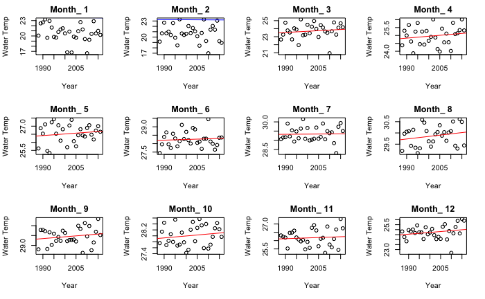

Each Month’s Average Water Temperature at Noon from 1987 to 2016

## Conclusion

Based on the time series forecasting model, the seasonal trend for temperatures are not clear.

This analysis certainly contains its limitations. The data is collected at one location on this planet, and my analysis only accounts noon temperatures. Further investigations could include more data collection around the globe, include more variables like CO2 level, and study daily, seasonal, and yearly temperature fluctuations.

# Reference

Acknowledgements: Thanks to my teammates Zijie Huang, Ziyi Bai, Xiaozhou Lu, Yuxin Zeng who helped me to improve my method and coding.

Package reference:

R Core Team (2020). R: A language and environment for statistical computing. R Foundation for Statistical Computing, Vienna, Austria. URL https://www.R-project.org/.

Wickham et al., (2019). Welcome to the tidyverse. Journal of Open Source Software, 4(43), 1686, https://doi.org/10.21105/joss.01686

Goodrich B, Gabry J, Ali I & Brilleman S. (2020). rstanarm: Bayesian applied regression modeling via Stan. R package version 2.21.1 https://mc-stan.org/rstanarm.

Brilleman SL, Crowther MJ, Moreno-Betancur M, Buros Novik J & Wolfe R. Joint longitudinal and time-to-event models via Stan. StanCon 2018. 10-12 Jan 2018. Pacific Grove, CA, USA. https://github.com/stan-dev/stancon_talks/

Garrett Grolemund, Hadley Wickham (2011). Dates and Times Made Easy with lubridate. Journal of Statistical Software, 40(3), 1-25. URL http://www.jstatsoft.org/v40/i03/.

H. Wickham. ggplot2: Elegant Graphics for Data Analysis. Springer-Verlag New York, 2016.

David Stoffer (2020). astsa: Applied Statistical Time Series Analysis. R package version 1.10. https://CRAN.R-project.org/package=astsa

Yihui Xie (2020). knitr: A General-Purpose Package for Dynamic Report Generation in R. R package version 1.29.

Yihui Xie (2015) Dynamic Documents with R and knitr. 2nd edition. Chapman and Hall/CRC. ISBN 978-1498716963

Yihui Xie (2014) knitr: A Comprehensive Tool for Reproducible Research in R. In Victoria Stodden, Friedrich Leisch and Roger D. Peng, editors, Implementing Reproducible Computational Research. Chapman and Hall/CRC. ISBN 978-1466561595